# Chapter 3: In Class Examples

## Example 1: Time to Failure

Electronic Components are subjected to an accelerated life test. A sample of failure times is given below.

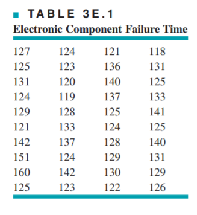

1. What is the average and standard deviation of the failure times?
2. Construct a histogram of the data. Add a title and set the number of bins to 5.
3. Increase the number of bins to 10 in a new plot.
4. Create a stem-and-leaf plot of the data.

## Example 2: Viscosity

Data on the viscosity of liquid substances is given in the table below. Construct a probability plot of the data for the normal, log-normal, and uniform distributions. Which distribution fits the data best?

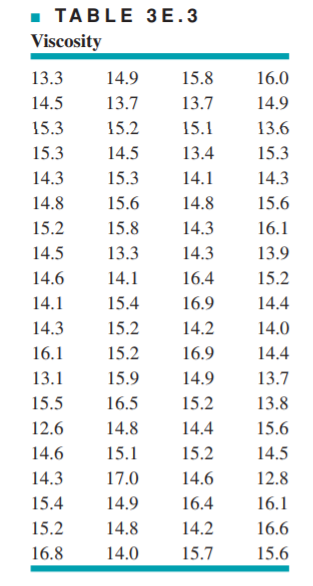

## Example 3: Tensile strength

The tensile strength of a metal part is normally distributed with mean 600 lb and standard deviation 50 lb.  
a. If 50,000 parts are produced, how many would you expect to fail to meet a minimum specification limit of 550 lb tensile strength?  
b. Use the standard normal table at the end of the book to verify question 1.  
c. What percentage of the parts will fall inbetween the range of 570 and 630?  
d. Verify the range using the standard normal tables in the back of the book.  
e. Find the tensile strength limits (upper and lower) that cover 80% of the production.

## Example 4: Mechatronic Assembly

A mechatronic assembly is subjected to a final functional test. Suppose that defects occur at random in these assemblies, and that defects occur according to a Poisson distribution with parameter lambda = 0.02.  
a What is the probability that an assembly will have exactly one defect? b What is the probability that an assembly will have one or more defects?

## Example 5: Defective Furnaces

The error rate for the production of furnances is .005. In a sample of 100 furnaces, given that you know the distribution is binomail, what is the probability there are exactly 5 broken furnaces?